# website upgrade outline

J-P Courneya

8/19/2021

# Homepage

At the top have some badges to connect to social accounts for the community

## Community News

How to integrate a newsfeed?

## Community History - Snippet

The village of Relay is halfway between Baltimore and Ellicott City. It was created in 1830 as a change point, or “relay,” for horses hauling the first scheduled railroad cars in the United States.

## Unique Community attributes

Historic Relay and St. Denis is a vibrant destination. Nearby is the glorious Patapsco State Park and National historic landmark Thomas Viaduct. Relay is a popular destination for train, recreation and exercise enthusiasts. The picturesque streets highlight the glory of historic Baltimore County Maryland.

- Well-preserved residential architecture
- Tradition of activism and community engagement
- Within Walking distance to Public Library and Senior Center
- Close to BWI
- MARC train to go to Washington DC.

## Community Location

A map of the Relay boundaries

## Relay Improvement Association and becoming a member

A small blurb about RIA link to page about the association?

call to action to become a memeber of the RIA and donate.

## Footer for the page

links to social media, maybe newsletter signup with reCAPTCHA

# History of Relay and St. Denis

Maybe open up with this narrative from the historian Ray Chism. [History of Relay](http://relaymaryland.com/Welcome_files/HistoryofRelay.pdf)

A video of the Relay community passage of time. [The Relay Community](https://www.youtube.com/watch?v=-4d6KkJX35Y&wide)

## Thomas viaduct

Some videos and content about the viaduct

[The Thomas Viaduct](https://www.youtube.com/watch?v=-tCcWP3CsJE&wide)

[The Thomas Viaduct Animation](https://www.youtube.com/watch?v=0HUQZMtOoHk&wide)

## World War 1 Service Banner

Story of the World War 1 service banner : [WWI Service Banner Restoration](https://www.youtube.com/watch?v=7S_g64RYziU&wide)

# Neighborhood

## Security

### Security and Safety Contact numbers

1. **In Case of Emergency**, or if you see a crime in progress, call BR Police Dispatch at 410-887-0872, or call 911. If a Garden District security patrol officer happens to already be in the area, Dispatch will call them.
2. **Security Patrol**: For ongoing security concerns regarding criminal activity in the neighborhood, you can call the police dispatch phone number at 410-887-0872. PLEASE always start your message with your name, address, and phone number.
3. **To discuss ongoing security concerns** regarding criminal activity, please fill out a contact form here and report your concern. Our board member in charge of security will reach out to you regarding your question.
4. **House Vacancies** If you would like to inform the GD Security Patrol that you’ll be out of town, you can submit a house [vacancy notice](https://resources.baltimorecountymd.gov/Documents/Police/2014pdfs/vacanthouseform141119.pdf) or email it to your [precinct](https://www.baltimorecountymd.gov/departments/police/precinctsgeneral/precinctsall.html).

### 5 Steps to a Safer Neighborhood

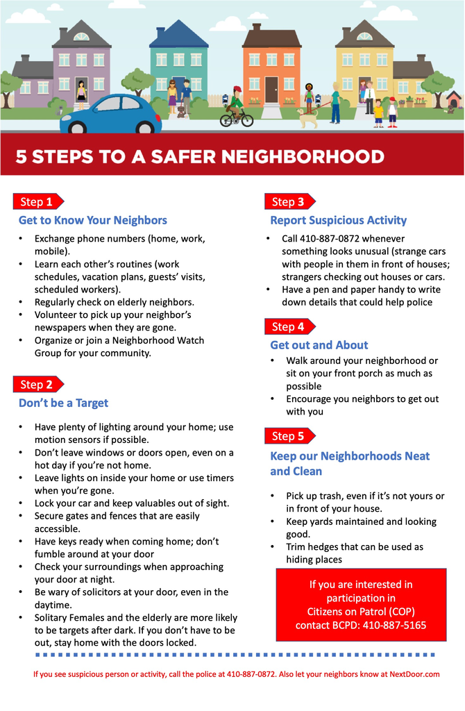

### Home Security Resources and Links

These home security links and resources will help you prepare a secure home and help you know what to do in the event of a problem. Please download and print for your records.

- Website for Baltimore County Police Department [Precinct 1 – Wilkens](https://www.baltimorecountymd.gov/departments/police/pc01/index.html)
- Baltimore County Police Department Crime prevention tips for Homeowners [link](https://www.baltimorecountymd.gov/departments/police/yoursafety/crimeprev_homes.html)
- Residential Security Surveys can be requested by reaching the Precinct 1 – Wilkens Outreach Unit at : **410-887-5165**
- Tips for non-emergency situations can also be submitted online via the department’s [iWatch Baltimore County tip form](https://www.baltimorecountymd.gov/departments/police/media/iWatch/index.html).

## Relay Historic District FAQ

It would be nice to embed this and make it navigatable.

[FAQ Flier](http://relaymaryland.com/Welcome_files/RelayFAQ2011.pdf)

# TownHall

# Relay Improvement Association

# News and Calendar

## News feed

The content for this feed will be synchronized with notifications typically sent through the listserv.

## Calendar

Google calendar feed like Zion?